# Lecture 1: Probability and Generative Models

Susan Holmes and Wolfgang Huber

June 26, 2017

# Generative Models and Discrete Data

Susan Holmes, June 2017 (c)

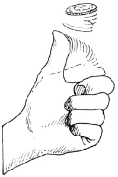

image

### Binary Data

- Mutations at each position the Reverse Transcriptase (RT) gene of HIV follows a Poisson(0.0005=5 . $10^{-4}$) distribution.
- $\longrightarrow$ Average number of mutations in the first 10,000 positions is 5, with a standard error of $\sqrt{5}$.

### Other Examples

- How many reads of DNA match a reference pattern?
- How many CG digrams we observe in a sequence.
- How many binding sites?

### Using discrete probability models for binary events

We use Poisson and Binomial distributions as models for binary outcomes.

# Poisson Model for rare events

In the HIV model above, suppose we want to find the probability of seeing 3 mutations in a sequence of length 10,000?

```r
dpois(x=3,lambda=5)
```

```
## [1] 0.14
```

There **is** a formula:
$$P(X=k)= \frac{\lambda^ke^{-\lambda}}{k!}
\mbox{
For }\lambda=5, \mbox{ we get }P(X=3)=\frac{5^3\times e^{-5}}{3\times 2}.$$

```r
(5^3*exp(-5))/6
```

```
## [1] 0.14
```

Mostly, we won’t need to know the formulas, just how to use R.

# Epitope Example

The molecular sites responsible for allergic reactions are called epitopes. We carry out an **ELISA** assay where we know the false positive rate is 0.01 (1 percent). P(Declare Epitope $|$ No Epitope) We take 50 patient samples over a protein tested at 100 positions. The data from one patient looks like this:

```
[1]  0 0 0 0 0 0 0 0 0 0 0 0 0 0 0 0 0 0 0 0 0 0 0 0 0 1 0 0 0 0 0 0 0 0 0
[36] 0 0 0 0 0 0 0 0 0 0 0 0 0 0 0 0 0 0 0 0 0 0 0 0 0 0 0 0 0 0 0 0 0 0 0
[71] 0 0 0 0 0 0 0 0 0 0 0 0 0 0 0 0 0 0 0 0 0 0 0 0 0 0 0 0 0 0
```

## Results from 50 assays

If there are no epitopes and the counts follow a Poisson(0.01) distribution. Each individual position and patient has a probability of 1 in 100 of being a 1.

At any given position after seeing 50 patients, we expect the sum to have a Poisson distribution with parameter 0.5.

# Binomial Success Counts

When we have a binary outcome (success/failure), (CpG/NonCpG), (M/F), (Y=Pyraminidine,R=Purine), (Diseased/Healthy), True/False.

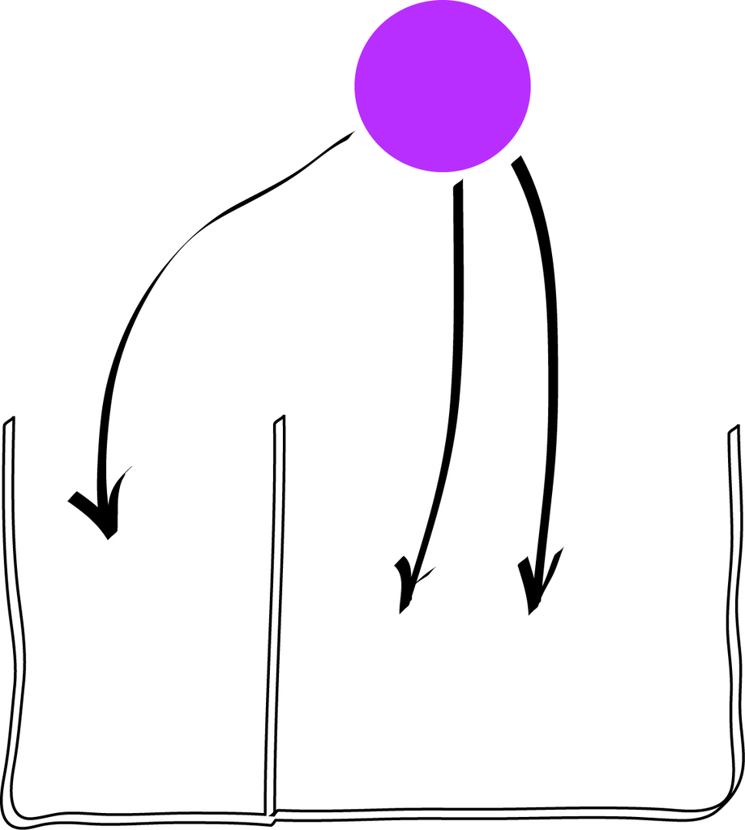

Balls in two Boxes

We can model it as a simple random variable with probability of success $p$ and failure $1-p$.

`SSSSSFSSSSFFFSF` is summarized as (#Success=10,#Failures=5).

The number of successes is said to have a Binomial distribution with parameters $prob=0.3$ and $size=15$.

### Let’s use R to explore the Binomial

We use special functions tailored for each type of distribution, `rbinom` for the binomial, `rmultimom` for the multinomial, `rpois` for the Poisson.

Each will need a different set of parameters to be fixed.

Suppose we wanted to simulate a sequence of fifteen fair coin tosses, then we write

```r
rbinom(15,prob=0.5,1)
```

```
##  [1] 0 0 1 1 1 1 1 1 1 0 1 0 1 1 1
```

```r
set.seed(235569511)
rbinom(1,prob=0.3,15)
```

```
## [1] 3
```

```r
rbinom(1,prob=0.3,15)
```

```
## [1] 5
```

```r
rbinom(1,prob=0.3,15)
```

```
## [1] 2
```

```r
rbinom(1,prob=0.3,15)
```

```
## [1] 5
```

```r
rbinom(1,prob=0.3,15)
```

```
## [1] 5
```

Notice that 5 comes out quite often, the theoretical proportion of times that 5 does come out is the value of the probability that X=5 for X a Binomial with n=15, p=0.3 and it’s complete distribution can be given by typing:

```r
vec15=dbinom(0:15,prob=0.3,15)
round(vec15,3)
```

```
##  [1] 0.005 0.031 0.092 0.170 0.219 0.206 0.147 0.081 0.035 0.012 0.003 0.001
## [13] 0.000 0.000 0.000 0.000
```

Here’s a plot of the theoretical distribution:

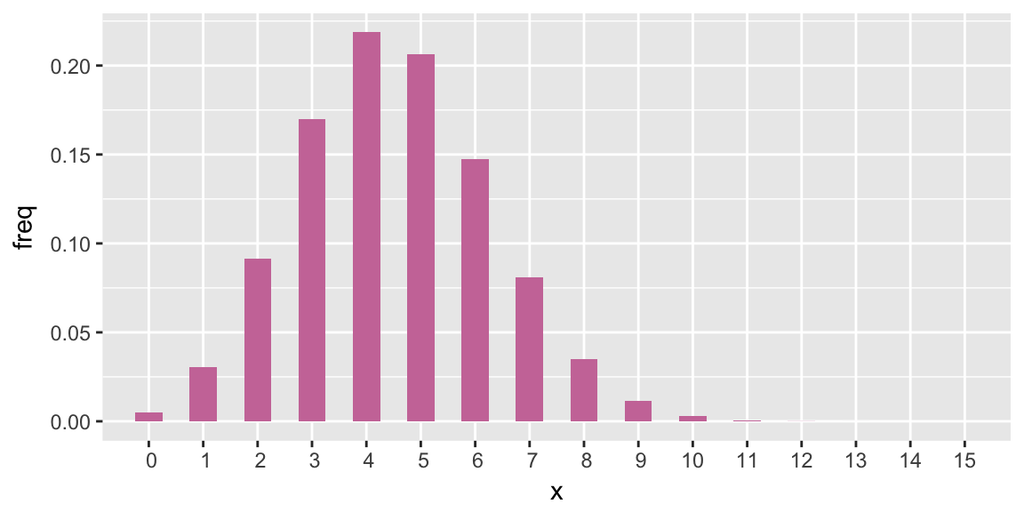

Theoretical Distribution of Binomial(15,0.3)

When we know the number of events, the parameter we call $n$ and when we know the probability of success, we can compute the probability of seeing k=5 successes

```r
dbinom(5,p=0.3,15)
```

```
## [1] 0.206
```

this actually uses a closed form formula:
$$P(X=k)= { n \choose k} p^k (1-p)^{n-k}$$

# Multinomial

Several possibilities for levels: (AA, Aa, aa)

Number of levels in a categorical variable can be very large.

If we are only measuring one categorical variable on a sample, we usually tally the frequencies of the different levels in a vector of counts.

```r
genotype1=c("AA", "AO", "BB", "AO", "OO", "AO", "AA", "BO", "BO", "AO", "BB",
            "AO", "BO", "AB", "OO", "AB", "BB", "AO", "AO")
table(genotype1)
```

```
## genotype1
## AA AB AO BB BO OO
##  2  2  7  3  3  2
```

We encode these variables as `factor` variables

```r
genotype=factor(genotype1)
genotype
```

```
##  [1] AA AO BB AO OO AO AA BO BO AO BB AO BO AB OO AB BB AO AO
## Levels: AA AB AO BB BO OO
```

```r
table(genotype)
```

```
## genotype
## AA AB AO BB BO OO
##  2  2  7  3  3  2
```

Let’s try a few experiments to see what some of these random variables look like.

Examples with 4 categories:

```r
rmultinom(1,prob=c(3/4,1/12,1/12,1/12),1)
```

```
##      [,1]
## [1,]    0
## [2,]    0
## [3,]    0
## [4,]    1
```

```r
rmultinom(1,prob=c(3/4,1/12,1/12,1/12),1)
```

```
##      [,1]
## [1,]    1
## [2,]    0
## [3,]    0
## [4,]    0
```

```r
rmultinom(1,prob=c(3/4,1/12,1/12,1/12),1)
```

```
##      [,1]
## [1,]    1
## [2,]    0
## [3,]    0
## [4,]    0
```

```r
rmultinom(1,prob=c(3/4,1/12,1/12,1/12),1)
```

```
##      [,1]
## [1,]    1
## [2,]    0
## [3,]    0
## [4,]    0
```

We could have replaced these four draws with one draw of 4:

```r
rmultinom(1,prob=c(3/4,1/12,1/12,1/12),size=4)
```

```
##      [,1]
## [1,]    4
## [2,]    0
## [3,]    0
## [4,]    0
```

```r
rmultinom(4,prob=c(3/4,1/12,1/12,1/12),size=1)
```

```
##      [,1] [,2] [,3] [,4]
## [1,]    0    1    0    1
## [2,]    0    0    1    0
## [3,]    0    0    0    0
## [4,]    1    0    0    0
```

## Multinomial Distribution: the formula

Here is the formula the programs use to compute the probability of a multinomial vector of counts $(x_1,\ldots,x_m)$ being observed:
$$\begin{eqnarray*}
P(x_1,x_2,\ldots,x_m | p_1,\ldots,p_m)&=&\frac{n!}{\prod x_i!}
\prod p_i^{x_i}\\
&=&{{n}\choose{x_1,x_2, x_m}} p_1^{x_1}p_2^{x_2}
\cdots p_m^{x_m}
\end{eqnarray*}$$

## Multinomial distributions: the case of DNA

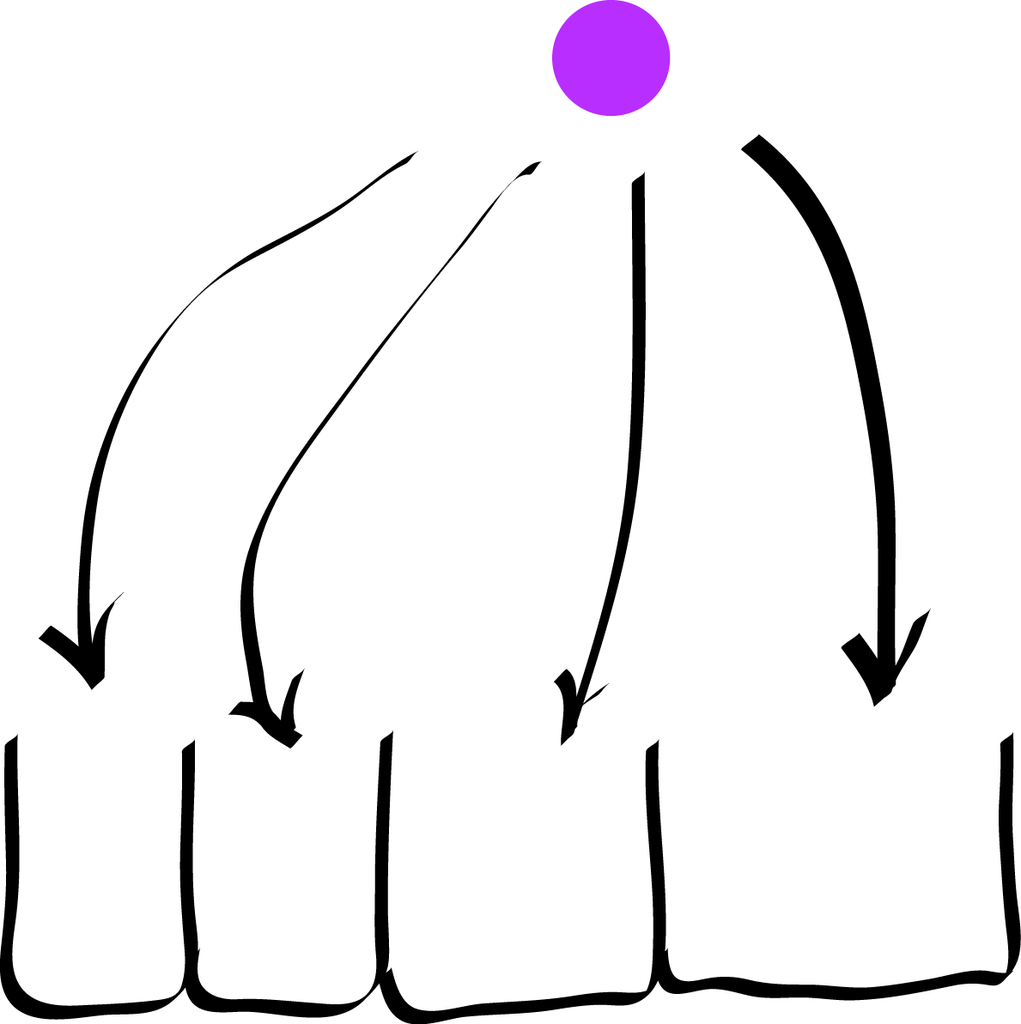

fig:ACGT:fourboxes

##### More than two outcomes

When modeling four possible outcomes as for instance the boxes in the figure above or when studying counts of the four nucleotides A,C,G and T , we need to extend the binomial model.

When using the binomial we can consider unequal probabilities for the two outcomes by assigning a probability $p=P(1)=p_1$ to the outcome 1 and $1-p=p(0)=p_0$ to the outcome 0. When there are more than two possible outcomes, say A,C,G and T , we can think of throwing balls into boxes of differing sizes corresponding to different probabilities, and we can label these probabilites $p_A,p_C,p_G,p_T$.

Just as in the binomial case the sum of the probabilities of all possible outcomes is 1, $p_A+p_C+p_G+p_T=1$.

##### Mathematical formulation

This is the most important model for tallying counts and R
uses a general formula to compute the probability of a **multinomial** vector of counts $(x_1,\ldots,x_m)$ for outcomes that have $m$ boxes with probabilities $p_1,\ldots,p_m$:
$$\begin{eqnarray*}
P(x_1,x_2,\ldots,x_m \;|\; p_1,\ldots,p_m)\\
&=&\frac{n!}{\prod x_i!}
\prod p_i^{x_i}\\
&=&{{n}\choose{x_1,x_2,\ldots,x_m}} p_1^{x_1}p_2^{x_2} \cdots p_m^{x_m}.
\end{eqnarray*}$$

Suppose we have four boxes that are equally likely. Using the formula, find what is the probability of observing 4 in the first box, 2 in the second box, and none in the two other boxes?

```r
dmultinom(c(4, 2, 0, 0), prob = rep(1/4, 4))
```

```
## [1] 0.00366
```

```r
pvec <- rep(1/4, 4)
t(rmultinom(1, prob = pvec, size = 8))
```

```
##      [,1] [,2] [,3] [,4]
## [1,]    5    1    1    1
```

### Simulating for power

Let’s see an example of using Monte Carlo for the **multinomial** in a way which is related to a problem scientists often have to solve when planning their experiments: how big a sample size do I need?

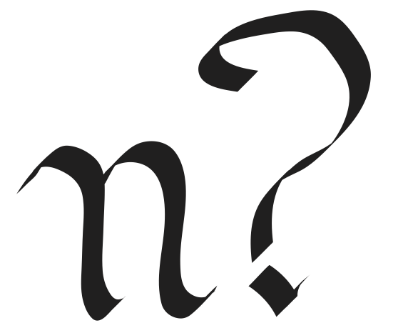

fig:n?

Conventionally, experimentalists aim for a power of 80% (or more) when planning experiments. This means that if the planned experiment is run many times, about 20% of the time it will fail to yield significant results when it should.

We will call $H_0$ the null hypothesis[^14] that the DNA data we have collected comes from a *fair* process where each of the 4 nucleotides is equally likely $(p_A,p_C,p_G,p_T)=(0.25,0.25,0.25,0.25)$. There are many examples of situations where the departure from this model. There are many situations where the process is not fair; in those situations, so-called nucleotide bias can help detect selective pressure and drug resistance

As you saw by running the R commands for 8 characters and 4 equally likely outcomes, represented by equal-sized boxes, we do not always get 2 in each box. It is impossible to say, from looking at just 8 characters, whether the nucleotides come from a fair process or not.

Let’s determine if, by looking at a sequence of length $n=20$, we can detect whether the original distribution of nucleotides is fair or whether it comes from an alternative process. We generate 1000 simulations from the null (fair) hypothesis using the function `rmultinom`, we display only the first 12 columns to save space.

```r
set.seed(3439)
obsunder0 = rmultinom(1000,prob=pvec,size=20)
obsunder0[,1:12]
```

```
##      [,1] [,2] [,3] [,4] [,5] [,6] [,7] [,8] [,9] [,10] [,11] [,12]
## [1,]    6    4    5    7    5    5    4    3    7     4     7     5
## [2,]    2    2    4    2    4    2    6    5    3     6     5     4
## [3,]    9    3    8    4    5    7    4    7    6     8     3     6
## [4,]    3   11    3    7    6    6    6    5    4     2     5     5
```

Each column in the matrix is a simulated instance. You can see that the numbers in the boxes vary a lot: some are as big as 11, whereas the expected value is 5=20/4.

#### Creating a test

Remember: we know these values come from a fair process. Clearly, knowing the process’ expected values isn’t enough. We also need a measure of variability that will allow us to describe how much variability is expected and how much is too much. We use as our measure a statistic computed as the sums of squares of the differences between the observed values and the expected values relative to the expected values. Thus, for each instance,
$${\tt stat}=\frac{(E_A-x_A)^2}{E_A}+
\frac{(E_C-x_C)^2}{E_C}+
\frac{(E_G-x_G)^2}{E_G}+
\frac{(E_T-x_T)^2}{E_T}
=\sum_i\frac{(E_i-x_i)^2}{E_i}$$
How much do the first two columns of the generated data differ from what we expect? We get:

```r
expected0=pvec*20
sum((expected0-obsunder0[,1])^2/expected0)
```

```
## [1] 6
```

```r
sum((expected0-obsunder0[,2])^2/expected0)
```

```
## [1] 10
```

As we expect, the values of the measure differ. To get a more complete picture of this variation we compute the measure for all 1000 instances (and store these values in a vector we call S0 because it contains values generated under $H_0$).

```r
S0=apply(obsunder0,2,function(x)sum((expected0-x)^2/expected0))
summary(S0)
```

```
##    Min. 1st Qu.  Median    Mean 3rd Qu.    Max.
##    0.00    1.20    2.80    3.08    4.40   19.60
```

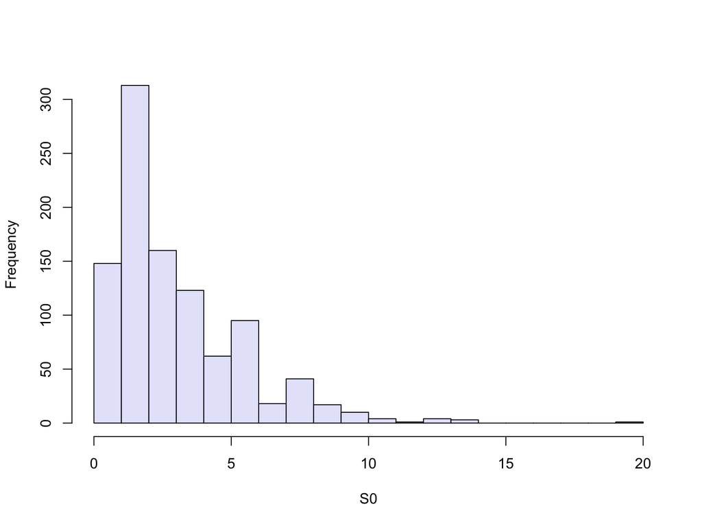

```r
hist(S0,20,col="lavender",main="")
```

The summary function shows us that S0 takes on a spread of different values, called a distribution for which we can compute 95% quantile (the value that separates the smaller 95% values from the 5% larger values).

```r
val=quantile(S0, probs=0.95)
val
```

```
## 95%
## 7.6
```

In response to our request for the 95% quantile, R tells us that are only 5% of the values are larger than 7.6. We’ll propose this as our critical value for testing data and will reject the hypothesis that the data come from a fair process, with equally likely nucleotides, if the weighted sum of squares stat is larger than 7.6.

#### Determining our test’s power

We must compute the probability that our test – the weighted sum-of-square differences – will detect when the data do in fact come from an alternative pvecA .

To compute this probability we generate 1000 simulated instances from the alternative process. These play the role of observations.

```r
pvecA = c(3/8, 1/4, 3/12, 1/8)
obsunderA = rmultinom(1000,prob=pvecA,size=20)
obsunderA[,1:12]
```

```
##      [,1] [,2] [,3] [,4] [,5] [,6] [,7] [,8] [,9] [,10] [,11] [,12]
## [1,]    6    7    3    7    8    5   10    5    8     8    10    11
## [2,]    7    7    4    4    4    7    5    9    3     6     3     4
## [3,]    5    2   10    7    7    7    4    6    7     3     5     2
## [4,]    2    4    3    2    1    1    1    0    2     3     2     3
```

```r
apply(obsunderA,1,mean)
```

```
## [1] 7.54 4.95 4.96 2.56
```

```r
expectedA=pvecA*20
expectedA
```

```
## [1] 7.5 5.0 5.0 2.5
```

As with the simulation from the null hypothesis, these numbers vary considerably. The question is: how often (out of 1000) instances will our test detect that the data depart from the null?

The test doesn’t reject the first observation, 6, 7, 5, 2, because the value of the statistic is within the 95th percentile:

```r
sum((expected0-obsunderA[,1])^2/expected0)
```

```
## [1] 2.8
```

```r
####Whole series of statistics under the alternative
stat1=apply(obsunderA,2,function(x)sum((x-expected0)^2/expected0))
val
```

```
## 95%
## 7.6
```

```r
sum(stat1>val)
```

```
## [1] 213
```

```r
power=sum(stat1>val)/1000
power
```

```
## [1] 0.213
```

**Task** Run across 1000 simulations, the test identified 213 as coming from an **alternative** **distribution** . We’ve thus computed that the probability $P(\mbox{reject }\;\; H_0 | H_A)$ is $0.213$.

With a sequence length of $n=20$ we have a power of about 21% to detect the difference between the fair generating process and our **alternative** .

In practice, as we mentioned, an acceptable value of power is $0.8$ or more. Repeat the simulation experiments and suggest a new sequence length $n$ that will ensure that the power is acceptable. $\nabla$

# Multinomial Model for nucleotides

## DNA Frequency Calculations

In the Labs:

- Biostrings
- BSgenome: different genomes
- Run a simulation experiment (parametric bootstrap)

```r
library(BSgenome.Celegans.UCSC.ce2)
Celegans
```

```
## Worm genome:
## # organism: Caenorhabditis elegans (Worm)
## # provider: UCSC
## # provider version: ce2
## # release date: Mar. 2004
## # release name: WormBase v. WS120
## # 7 sequences:
## #   chrI   chrII  chrIII chrIV  chrV   chrX   chrM
## # (use 'seqnames()' to see all the sequence names, use the '$' or '[[' operator
## # to access a given sequence)
```

```r
seqnames(Celegans)
```

```
## [1] "chrI"   "chrII"  "chrIII" "chrIV"  "chrV"   "chrX"   "chrM"
```

```r
afM=alphabetFrequency(Celegans$chrM)
afM[1:4]
```

```
##    A    C    G    T
## 4335 1225 2055 6179
```

```r
sum(afM[1:4])
```

```
## [1] 13794
```

```r
s1=rmultinom(1,100,p=c(1/4,1/4,1/4,1/4))
s2=rmultinom(1,13794,p=c(1/4,1/4,1/4,1/4))
```

## Is this consistent with a uniform (1/4,1/4,1/4,1/4)?

```r
mystat=function(exp,obs){
  out=sum((exp-obs)^2/exp)
  return(out) }
exp=c(3448,3449,3448,3449)
obs=afM[1:4]
obs
```

```
##    A    C    G    T
## 4335 1225 2055 6179
```

```r
mystat(exp,obs)
```

```
## [1] 4386
```

```r
exp=rmultinom(1,13794,p=c(1/4,1/4,1/4,1/4))
mystat(exp,obs)
```

```
## [1] 4474
```

### Is this larger than what randomness could explain?

Under the null model we might see an observation of:

```r
x=rep(round(13794/4),4)
x=as.vector(x);names(x)=c("A","C","G","T")
rm=rmultinom(1,13794,p=c(1/4,1/4,1/4,1/4))
mystat(exp=x,obs=rm)
```

```
## [1] 1.08
```

### Need a whole set (distribution) of values

```r
mystatsundernull=function(x,N=13794,B=1000,p=c(1/4,1/4,1/4,1/4)){
  out=rep(0,B)
  obsmatrix=rmultinom(B,N,p=c(1/4,1/4,1/4,1/4))
  for ( b in 1:B){
    out[b]=mystat(exp=x,obs=obsmatrix[,b])
    }
  return(out)
}

resundernull=mystatsundernull(x,B=10000)
```

#### Compare this to what we saw

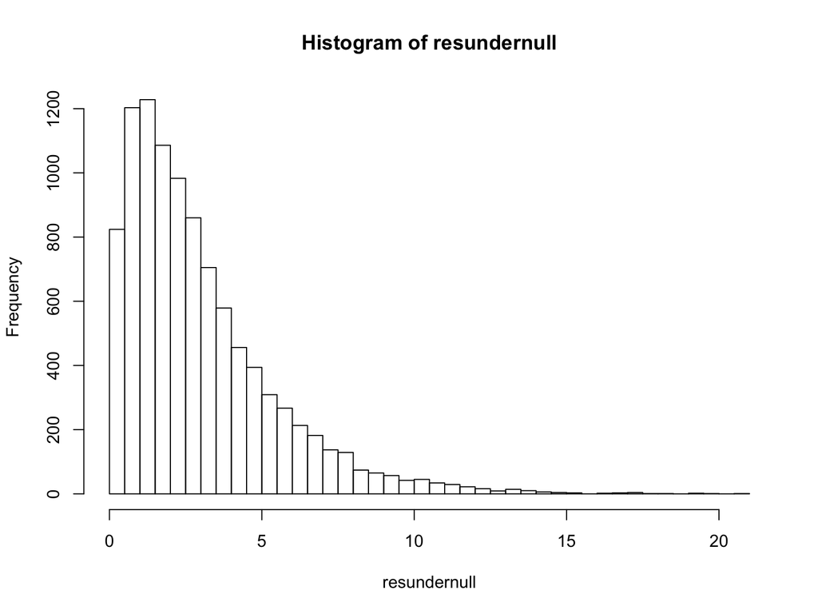

```r
hist(resundernull,30)
```

```r
mystat(exp,obs)
```

```
## [1] 4474
```

### We actually didn’t need to simulate

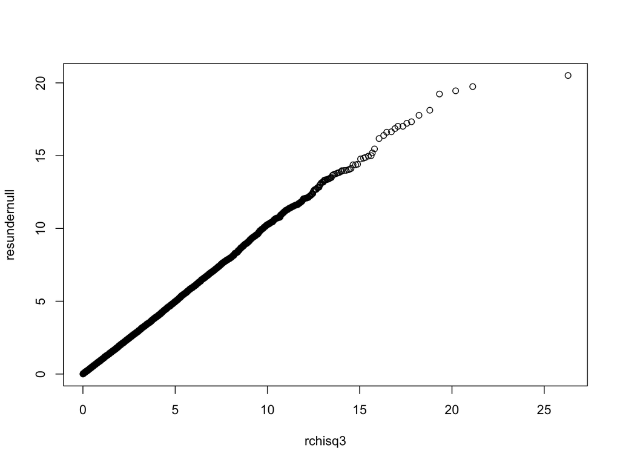

```r
rchisq3=rchisq(100000,3)
qqplot(rchisq3,resundernull)
```

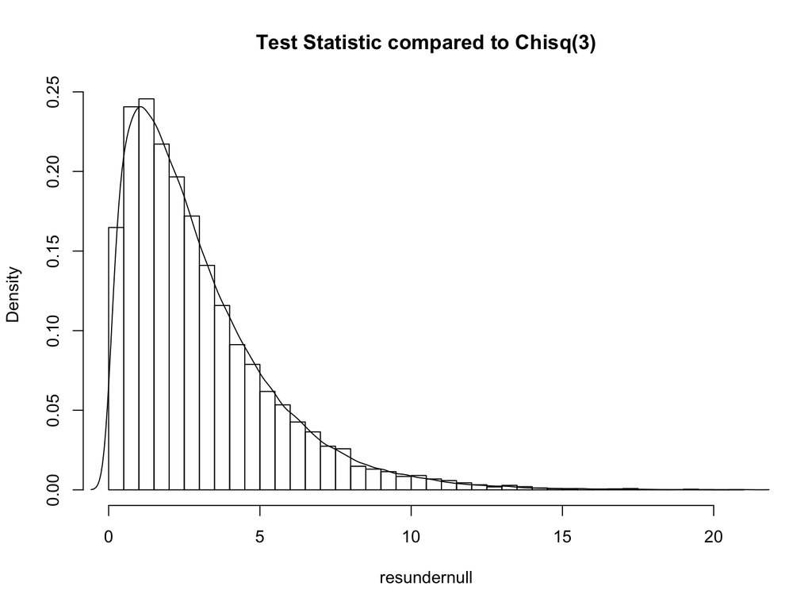

```r
hist(resundernull,50,prob=TRUE,main="Test Statistic compared to Chisq(3)")
lines(density(rchisq3))
```

## Conclusion

Shows that $P_{H_0}($ statistic as large as 4474$)$ smaller than $10^{-4}$.

We call $H_0$ the null hypothesis that the underlying proportions of the multinomial were $(p_A,p_C,p_G,p_T)=(0.25,0.25,0.25,0.25)$

We also write that probability

$P($ Observed stat $>$ 4474 $\vert H_{0})$. We read the vertical line as **given** or **conditional on**.

We rejected the null $H_0$ that the underlying proportions of the multinomial were $(p_A,p_C,p_G,p_T)=(0.25,0.25,0.25,0.25)$

# Poisson

[figure not shown]

When an event is quite rare, like a mutation, the number of times it occurs follows a Poisson distribution.

If we only look at one trial, most of the time, we won’t see anything.

For 1000 positions of the RT gene, and each mutation occurs independently at rate 0.02 then we would expect to see 20 mutations (1000 $\times$ 0.02= $n \times p$).

In general if an event has probability p and and we have n trials, this number is random with a Poisson distribution with mean parameter $\lambda$ equal to np.

```r
sum(rpois(1000,lambda=0.02))
```

```
## [1] 15
```

If you do this quite a few times, you’ll how the values you get differ, we get a distribution of values centered around 20 or so.

## Using probabilistic (generative) models for Epitope Detection

When testing certain pharmaceutical compounds it is important to detect proteins that provoke an allergic reaction, the sites that are responsible for such reactions are called epitopes.

The technical definition of an Epitope is: *A specific potion of a macromolecular antigen to which an antibody binds*.

An antibody http://ghr.nlm.nih.gov/ghr/glossary/antibody is type of protein made by certain white blood cells in response to the foreign substance which is called the antigen.

Each antibody can bind to only a specific antigen.

The purpose of this binding is to help destroy the antigen.

Some antibodies destroy antigens directly.

An epitope (or antigenic determinant), is the part of an antigen that is recognized by the immune system

## Known Parameters of the Measurements

ELISA detect specific epitopes along proteins.

- The baseline noise level per position is 1% (False positive rate), that is the probability of declaring a hit (that we have an epitope) when it is not there is 0.01.
- The length of the protein tested is 100 positions.
- We are going to examine a collection of 50 patient samples.

## One patient’s data

The data for one patient looks like this

```
##   [1] 0 0 0 0 0 0 0 0 0 0 0 0 0 0 0 0 0 0 0 0 0 0 0 0 0 1 0 0 0 0 0 0 0 0 0
##  [36] 0 0 0 0 0 0 0 0 0 0 0 0 0 0 0 0 0 0 0 0 0 0 0 0 0 0 0 0 0 0 0 0 0 0 0
##  [71] 0 0 0 0 0 0 0 0 0 0 0 0 0 0 0 0 0 0 0 0 0 0 0 0 0 0 0 0 0 0
```

where the 1 signifies a reaction or a `hit` and the zeros signify no reaction at that position.

## Results from the 50 assays

Typical of 100 positions tallies of hits for all 50 patient assays.

If the counts follow a Poisson distribution.

Each individual position and patient has a probability of 1 in 100 of being a 1. At any given position after seeing 50 patients, we expect the sum to have a Poisson distribution with parameter 0.5.

**Question:** Run a little simulation experiment to show that looking at the sum of 50 Poisson(0.01) variables will be like looking at one Poisson(0.5) random variable.

**Answer**

```r
x50=sum(rpois(50,0.01))
x50
```

```
## [1] 0
```

```r
x50=sum(rpois(50,0.01))
x50
```

```
## [1] 1
```

```r
x50=sum(rpois(50,0.01))
x50
```

```
## [1] 1
```

```r
x50=sum(rpois(50,0.01))
x50
```

```
## [1] 1
```

```r
set.seed(5427121)
m50=matrix(rpois(5000,0.01),ncol=100,nrow=50)
s100=apply(m50,2,sum)
table(s100)
```

```
## s100
##  0  1  2  3
## 68 21  7  4
```

```r
t100=rpois(100,0.5)
table(t100)
```

```
## t100
##  0  1  2  3
## 68 20 10  2
```

```r
mean(s100)
```

```
## [1] 0.47
```

```r
mean(t100)
```

```
## [1] 0.46
```

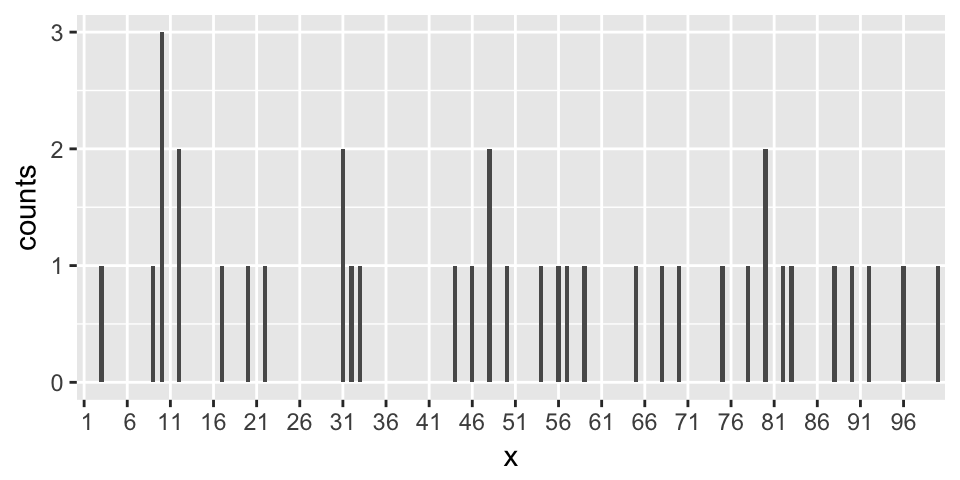

Plot of 100 draws from a Poisson(0.5)

Suppose that the actual data we see is the following:

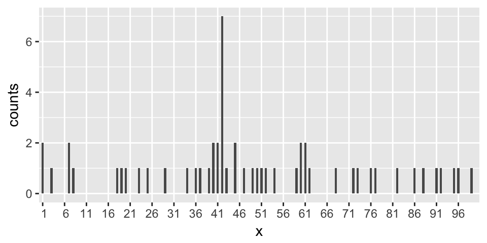

Output of Elisa array on 50 patients in 100 positions

We see a surprising spike and have to answer the question:

**What are the chances of seeing a value as large as 7?**

If we only look for the probability of seeing a number as big as 7 when considering one Poisson($0.5$) random variable.
$$P(X\geq 7)= 1-P(X\leq 6)=1-F_{Pois}(6)=1-ppois(6,0.5)$$
I’ll call this number $\epsilon$, how big is it?

```r
##Here are the cumulative function values for 0 to 6
round(ppois(0:6,0.5),5)
```

```
## [1] 0.607 0.910 0.986 0.998 1.000 1.000 1.000
```

```r
##What are the chances of seeing a value strictly bigger than 6?
1-ppois(6,0.5)
```

```
## [1] 1e-06
```

**Is this right?**

# Wrong computation in this case.

This would actually not be the correct computation.

We looked at all 100 positions and 7 was chosen because it was the maximum, so we have to ask ourselves what are the chances of seeing a number as large in 100 trials.

We use **extreme value** theory here. We order the values $x_1,x_2,\ldots x_n$ renaming them $x_{(1)},x_{(2)},x_{(3)}\ldots x_{(100)}$ so that $x_{(100)}$ denotes the maximum of the counts over the 100 positions.

For the largest to be as large as 7 is the **complementary event** (opposite) of having all 100 counts be smaller or equal to 6.

$$P(x_{(100)}\geq 7)=1-P(x_{(100)} \leq 6)=1-
\Pi_{i=1}^{100} P(x_i \leq 6 )$$
(supposing independence)
$$\Pi_{i=1}^n P(x_i < 7)=\left(\sum_{k=0}^{6}
\frac{e^{-\lambda} \lambda^k}{k!}\right)^{100}=
\left(1-\sum_{k=7}^{\infty}
\frac{e^{-\lambda} \lambda^k}{k!}\right)^{100}$$
(supposing identically dist. Poisson)

## Estimating small numbers

$\epsilon= \sum_{k=7}^{\infty} \frac{e^{-\lambda} \lambda^k}{k!}=P(x_i\geq 7)=1.00238.10^{-6}$.

Using this we can compute

$$\Pi_{i=1}^{100} P(x_i < 7)=(1-1.00238 .10^{-6})^{100}$$

We use the approximation $\log(1-\epsilon)\simeq -\epsilon$.

$$\left(1-\epsilon \right)^{100}
=\exp ( 100 \log (1-\epsilon))=\exp({- 100 \epsilon})
=e^{-100 P(x_i\geq 7)}=e^{-100\times 10^{-6}}=e^{-10^{-4}}$$

So that
$$P(x_{(100)}\geq 7)= 1-exp(-10^{-4}) =9.9995\; .\; 10^{-5}$$

We could also do this by simulation, or what is known as the Monte Carlo method (it involves throwing a lot of dies).

## Why is this better than by simulation (Monte Carlo) ?

Do not run this as it takes quite a lot of time and memory (on a 4GB machine this computation took about an hour, whereas the small analytic approximation above took 2 minutes)

```
M100=rpois(1000000000,0.5)
table(M100)
Matrix100=matrix(M100,ncol=100)
vecmaxes=apply(Matrix100,1,max)
table(vecmaxes)
```

giving an approximation of $9.48. 10^{-5}$ for $P(X_{max}\geq 7)$ and $3.10^{-7}$ for $P(X_{max}\geq 9)$.

```
million=rpois(1000000,0.5)
mat100=matrix(million,ncol=100)
maxes100=apply(mat100,1,max)
table(maxes100)

## maxes100
##   1    2    3    4    5    6
##   2 2338 6053 1432  163   12
```

We can only conclude that $P(max \geq 7)<10^{-4}$. So although it is doable to find small probabilities by simulation it is not always optimal.

Everything we have done up to now was under the probabilistic model possible because we knew the false positive rate per position, we knew the number of patients assayed and the length of the protein, there were no unknown parameters.

## Conclusion for this study

We postulated the Poisson distribution for the noise and were able to conclude through mathematical deduction.

This is a **Probability or Generative Model** because all the parameters were known and the mathematical theory allowed us to conclude by **deduction**

Now suppose that we knew the number of patients and the length of the proteins and we observed the data from an unknown distribution then we would have to use **Statistical Modeling** that will be developed in the next lecture.

# Important things we learnt today

- We have learned several ways to model count data, the Poisson, Binomial and Multinomials.
- We learnt how to generate random discrete data using the specialized R functions tailored for each type of distribution.
- The epitope example showed us how to use a probability model to compute a probability under a parametric model when the parameter was known. This probability was in fact so small it would even have been hard to compute by Monte Carlo simulation.
- P values are calculated from probabilities under certain assumptions. We will use probability distributions and probabilistic models to evaluate many of our results and compute both p-values and probabilities of our hypotheses being verified by the data.

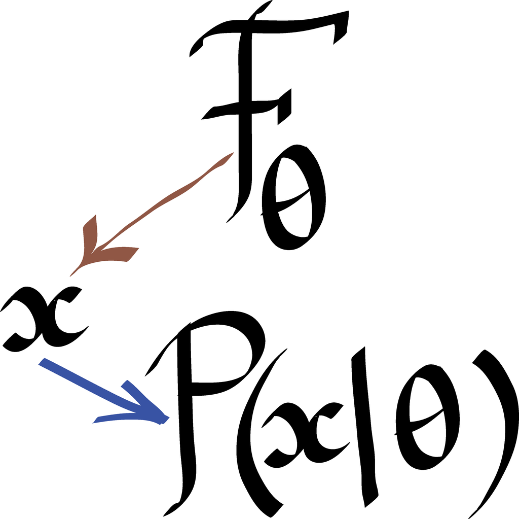

Down

## R note about known distributions

All known distributions can be used to simulate data using the functions that start `rXXXX` where `XXXX` could be `pois`, `binom`, `multinom`. If we need a theoretical computation of a probability under one of these models, we would use the functions `dXXXX`, such as `dpois`.

This also works for distributions that are not counts, such the Gaussian ( rnorm, dnorm), the $\chi^2$ ( rchisq, dchisq) or the exponential ( rexp, dexp).

## R Note:

Functions are useful for generalizing useful sequences of commands

```r
#########Argument by default for the Poisson take 0.5, for protein length take n=100
#########Function to compute the probability of having a maximum out of n as big as max
pmax=function(lam=0.5,n=100,max=7){
epsilon=1-ppois(max-1,lam)
proba=1-exp(-n*epsilon)
return(proba)
}
pmax(lam=0.5)
```

```
## [1] 1e-04
```

```r
pmax(lam=mean(e100))
```

```
## [1] 0.000187
```